# 作业1: 数据探索性分析与数据预处理

322010840 刘聪聪

## 1. 问题描述

自行选择2个数据集进行探索性分析与预处理。

所选数据集：

wine-reviews

## 2.数据集

wine-reviews

一共2个csv文件

- winemag-data_first150k.csv

包含10列和15万条葡萄酒评论

包含10列和13万行葡萄酒评论

导入库

```python
import matplotlib
import numpy as np
import pandas as pd
%matplotlib inline
```

载入数据

```python
path_15k = "data/wine-reviews/winemag-data_first150k.csv"
path_13k = "data/wine-reviews/winemag-data-130k-v2.csv"
data_15k = pd.read_csv(path_15k)
```

数据的属性

```python
data_15k.head(5)
```

|  | Unnamed: 0 | country | description | designation | points | price | province | region_1 | region_2 | variety | winery |
| --- | --- | --- | --- | --- | --- | --- | --- | --- | --- | --- | --- |
| 0 | 0 | US | This tremendous 100% varietal wine hails from ... | Martha's Vineyard | 96 | 235.0 | California | Napa Valley | Napa | Cabernet Sauvignon | Heitz |
| 1 | 1 | Spain | Ripe aromas of fig, blackberry and cassis are ... | Carodorum Selección Especial Reserva | 96 | 110.0 | Northern Spain | Toro | NaN | Tinta de Toro | Bodega Carmen Rodríguez |
| 2 | 2 | US | Mac Watson honors the memory of a wine once ma... | Special Selected Late Harvest | 96 | 90.0 | California | Knights Valley | Sonoma | Sauvignon Blanc | Macauley |
| 3 | 3 | US | This spent 20 months in 30% new French oak, an... | Reserve | 96 | 65.0 | Oregon | Willamette Valley | Willamette Valley | Pinot Noir | Ponzi |
| 4 | 4 | France | This is the top wine from La Bégude, named aft... | La Brûlade | 95 | 66.0 | Provence | Bandol | NaN | Provence red blend | Domaine de la Bégude |

```python
data_15k.dtypes
```

```
Unnamed: 0       int64
country         object
description     object
designation     object
points           int64
price          float64
province        object
region_1        object
region_2        object
variety         object
winery          object
dtype: object
```

- country 国家
- desprition 描述
- designation 葡萄酒庄
- pints 得分
- price 价格
- province 省份
- region_1 区域1
- region_2 区域2
- variety 葡萄种类
- winery 酿酒厂

## 3. 数据分析

### 3.1 数据可视化与摘要

#### 3.1.1 country属性

标称属性，给出每个可能聚会的频数

```python
attri = "country"
data_15k[attri].value_counts(dropna = False)
```

```
US                        62397
Italy                     23478
France                    21098
Spain                      8268
Chile                      5816
Argentina                  5631
Portugal                   5322
Australia                  4957
New Zealand                3320
Austria                    3057
Germany                    2452
South Africa               2258
Greece                      884
Israel                      630
Hungary                     231
Canada                      196
Romania                     139
Slovenia                     94
Uruguay                      92
Croatia                      89
Bulgaria                     77
Moldova                      71
Mexico                       63
Turkey                       52
Georgia                      43
Lebanon                      37
Cyprus                       31
Brazil                       25
Macedonia                    16
Serbia                       14
Morocco                      12
England                       9
Luxembourg                    9
India                         8
Lithuania                     8
Czech Republic                6
Ukraine                       5
NaN                           5
Bosnia and Herzegovina        4
Switzerland                   4
South Korea                   4
Egypt                         3
China                         3
Slovakia                      3
Montenegro                    2
Tunisia                       2
Albania                       2
Japan                         2
US-France                     1
Name: country, dtype: int64
```

使用直方图可视化

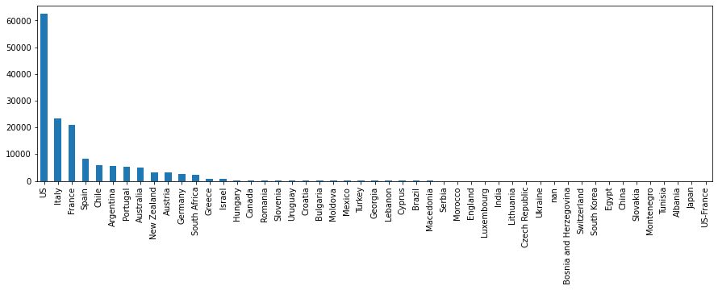

```python
data_15k[attri].value_counts(dropna = False).plot(kind="bar",figsize=(15,4))
```

#### 3.1.2 designation属性

标称属性，给出每个可能聚会的频数

```python
attri = "designation"
data_15k[attri].value_counts(dropna = False)
```

```
NaN                                45735
Reserve                             2752
Reserva                             1810
Estate                              1571
Barrel sample                       1326
                                   ...
Clos de l'Ermitage                     1
Brut Cuvèe 4 Millesimato               1
Amberhill                              1
Podere le Giarette                     1
Sauvignon Blanc Ruster Ausbruch        1
Name: designation, Length: 30622, dtype: int64
```

使用直方图可视化，只显示前50项

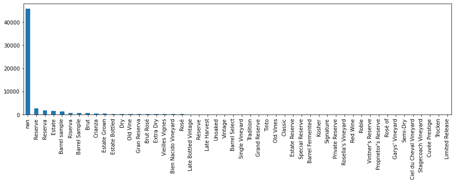

```python
data_15k[attri].value_counts(dropna = False)[:50].plot(kind="bar",figsize=(15,4))
```

#### 3.1.3 province属性

标称属性，给出每个可能聚会的频数

```python
attri = "province"
data_15k[attri].value_counts(dropna = False)
```

```
California         44508
Washington          9750
Tuscany             7281
Bordeaux            6111
Northern Spain      4892
                   ...
Waitaki Valley         1
Dalmatian Coast        1
Pafos                  1
Ticino                 1
Ioannina               1
Name: province, Length: 456, dtype: int64
```

使用直方图可视化，只显示前50项

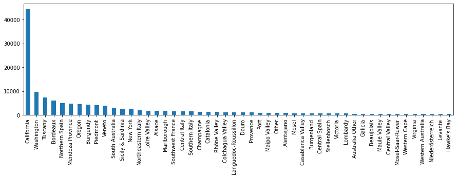

```python
data_15k[attri].value_counts(dropna = False)[:50].plot(kind="bar",figsize=(15,4))
```

#### 3.1.3 region_1属性

标称属性，给出每个可能聚会的频数

```python
attri = "region_1"
data_15k[attri].value_counts(dropna = False)
```

```
NaN                                   25060
Napa Valley                            6209
Columbia Valley (WA)                   4975
Mendoza                                3586
Russian River Valley                   3571
                                      ...
Valle d'Aosta                             1
Vin de Pays des Coteaux de Murviel        1
Erbaluce di Caluso                        1
Napa Valley-Paso Robles                   1
Ramandolo                                 1
Name: region_1, Length: 1237, dtype: int64
```

使用直方图可视化,只显示前50项

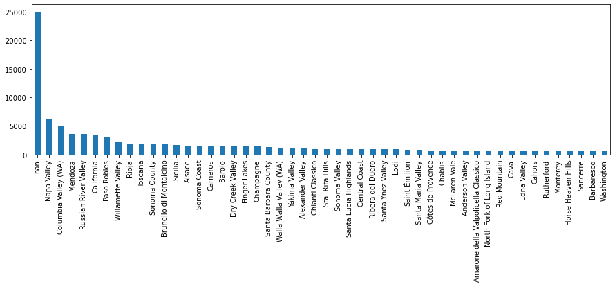

```python
data_15k[attri].value_counts(dropna = False)[:50].plot(kind="bar",figsize=(15,4))
```

#### 3.1.4 region_2属性

标称属性，给出每个可能聚会的频数

```python
attri = "region_2"
data_15k[attri].value_counts(dropna = False)
```

```
NaN                        89977
Central Coast              13057
Sonoma                     11258
Columbia Valley             9157
Napa                        8801
California Other            3516
Willamette Valley           3181
Mendocino/Lake Counties     2389
Sierra Foothills            1660
Napa-Sonoma                 1645
Finger Lakes                1510
Central Valley              1115
Long Island                  771
Southern Oregon              662
Oregon Other                 661
North Coast                  632
Washington Other             593
South Coast                  198
New York Other               147
Name: region_2, dtype: int64
```

使用直方图可视化

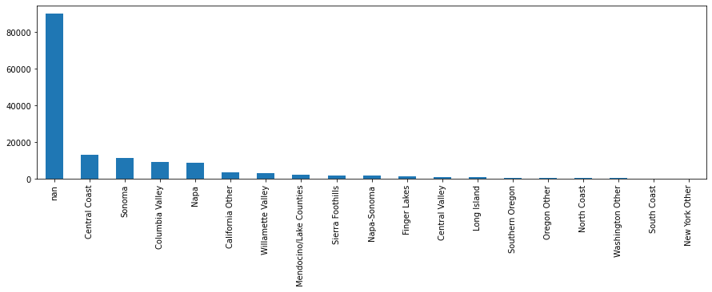

```python
data_15k[attri].value_counts(dropna = False).plot(kind="bar",figsize=(15,4))
```

#### 3.1.5 variety属性

标称属性，给出每个可能聚会的频数

```python
attri = "variety"
data_15k[attri].value_counts(dropna = False)
```

```
Chardonnay                  14482
Pinot Noir                  14291
Cabernet Sauvignon          12800
Red Blend                   10062
Bordeaux-style Red Blend     7347
                            ...
Petit Meslier                   1
Vidadillo                       1
Tempranillo-Malbec              1
Früburgunder                    1
Carineña                        1
Name: variety, Length: 632, dtype: int64
```

使用直方图可视化,只显示前80项

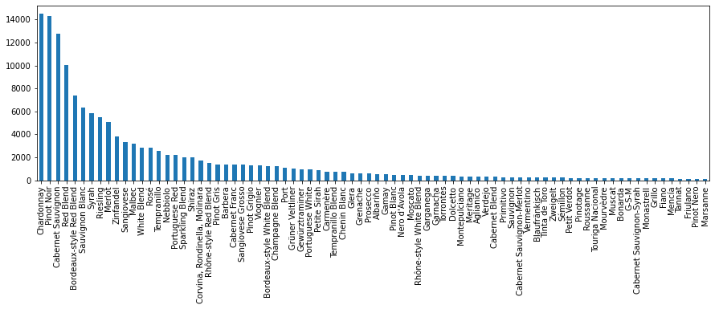

```python
data_15k[attri].value_counts(dropna = False)[:80].plot(kind="bar",figsize=(15,4))
```

#### 3.1.6 winery属性

标称属性，给出每个可能聚会的频数

```python
attri = "winery"
data_15k[attri].value_counts(dropna = False)
```

```
Williams Selyem               374
Testarossa                    274
DFJ Vinhos                    258
Chateau Ste. Michelle         225
Columbia Crest                217
                             ...
Château Thivin                  1
Chimere                         1
Château Marion d'Audren         1
Alexanderfontein                1
Domaine Machard de Gramont      1
Name: winery, Length: 14810, dtype: int64
```

使用直方图可视化,只显示前80项

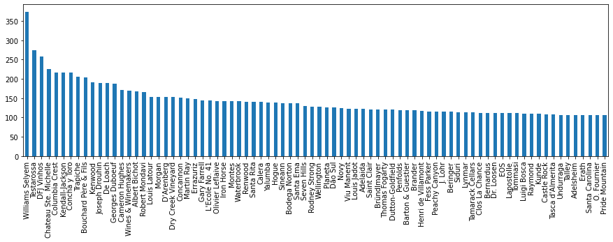

```python
data_15k[attri].value_counts(dropna = False)[:80].plot(kind="bar",figsize=(15,4))
```

#### 3.1.7 points属性

数值属性，给出五数概括

```python
attri = "points"
for i in range(0,5):
    q = i * 0.25
    print("Q%d:"%(i),end=" ")
    print(data_15k[attri].quantile(q))
```

```
Q0: 80.0
Q1: 86.0
Q2: 88.0
Q3: 90.0
Q4: 100.0
```

绘制盒图

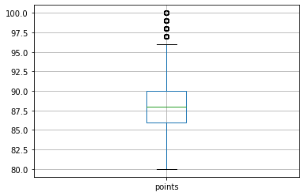

```python
p = data_15k.boxplot([attri],return_type='dict')
```

检查离群点

```python
print(p['fliers'][0].get_ydata())
print("MIN: ",end="")
print(min(p['fliers'][0].get_ydata()))
```

```
[100  99  98  98  98  97  97  97  97  97  97  97  97  97  97  97  97  97
  97  97  97  97  97  98  97  98  97  97  97  97  97  97  98  97  97  97
  97  97  97  98  97  97  97  97  97  97  97  97 100 100  99  99  98  98
  98  98  98  98  97  97  97  97  97  97  98  98  98  98  97  97  97  97
  97  97  97  98  97  97  97  97 100  99  99  98  98  98  98  98  98  97
  97  97  97 100  99  98  97  97  97  97  97  97  97  97  97  99  97  98
  97  97  97  97  97  97 100  98  98  97  97  97  97  97  97  97  97  97
  97  97  97  97  97  97  97  97  97  99  97  97  99  99  99  98  98  98
  98  98  97  97  97  97  97  97  99  97  97  97  97  97  97  97  97  97
 100  99  99  98  98  98  98  98  98  97  97  97  97  97  99  99  98  97
  97  97  97  97  98  98  97  97  97  97  97 100  99  98  97  97  97  97
  97  97  98  97  97  97  97  97  97  97  99  99  99  98  98  98  98  97
  97  97  97  97  97  97  97  97  97  97  97  97  98  97  97  97  98  98
  97  98  99  98  98  97  97  97  97  97  99  98  97  97  97  97  98  97
  97  97  97  97  97  97  97  97  97  97 100  98  98  97  97  97  97  97
```

[output cut: 18 more lines]

因此，points中大于等于97的项被识别为离群点。

#### 3.1. price属性

数值属性，给出五数概括

```python
attri = "price"
for i in range(0,5):
    q = i * 0.25
    print("Q%d:"%(i),end=" ")
    print(data_15k[attri].quantile(q))
```

```
Q0: 4.0
Q1: 16.0
Q2: 24.0
Q3: 40.0
Q4: 2300.0
```

绘制盒图

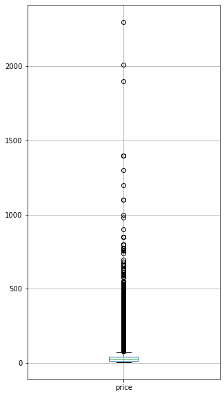

```python
p = data_15k.boxplot([attri],return_type='dict',figsize=(5,10))
```

检查离群点

```python
print(p['fliers'][0].get_ydata())
print("MIN: ",end="")
print(min(p['fliers'][0].get_ydata()))
```

```
[235. 110.  90. ...  83. 100.  87.]
MIN: 77.0
```

因此，price中大于等于77的项被识别为离群点。

## 3.2 处理数据缺失

首先统计所有属性的缺失值

```python
print(data_15k.isnull().sum(axis=0))
```

```
Unnamed: 0         0
country            5
description        0
designation    45735
points             0
price          13695
province           5
region_1       25060
region_2       89977
variety            0
winery             0
dtype: int64
```

### 3.2.1 处理country属性缺失

可能原因是人为失误，通过属性的相关关系来填补缺失值，使用designation的属性来判断所属国家

根据空值的分布，定义一个从designation到country的转换字典

```python
attri = "country"
designation2country = {
    "Askitikos":"Greece",
    "Shah":"US",
    "Piedra Feliz":"Chile",
}
```

处理缺失

```python
data_15k_new = data_15k.iloc[:,:]
for i in range(0,len(data_15k_new)):
    tmp = data_15k_new.iloc[i,1]
    if pd.isnull(tmp):
        designation = data_15k_new.iloc[i,3]
        data_15k_new.iloc[i,1] = designation2country[designation]
data_15k_new[attri].value_counts(dropna = False)
```

```
US                        62398
Italy                     23478
France                    21098
Spain                      8268
Chile                      5819
Argentina                  5631
Portugal                   5322
Australia                  4957
New Zealand                3320
Austria                    3057
Germany                    2452
South Africa               2258
Greece                      885
Israel                      630
Hungary                     231
Canada                      196
Romania                     139
Slovenia                     94
Uruguay                      92
Croatia                      89
Bulgaria                     77
Moldova                      71
Mexico                       63
Turkey                       52
Georgia                      43
Lebanon                      37
Cyprus                       31
Brazil                       25
Macedonia                    16
Serbia                       14
Morocco                      12
England                       9
Luxembourg                    9
Lithuania                     8
India                         8
Czech Republic                6
Ukraine                       5
South Korea                   4
Switzerland                   4
Bosnia and Herzegovina        4
China                         3
Slovakia                      3
Egypt                         3
Montenegro                    2
Albania                       2
Tunisia                       2
Japan                         2
US-France                     1
Name: country, dtype: int64
```

可视化对比

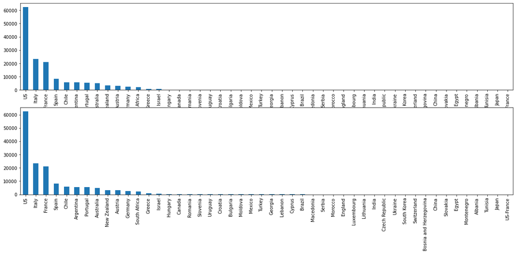

```python
attri = "country"
matplotlib.pyplot.subplot(2,1,1)
data_15k[attri].value_counts(dropna = False).plot(kind='bar',figsize=(20,8))
matplotlib.pyplot.subplot(2,1,2)
data_15k_new[attri].value_counts(dropna = False).plot(kind='bar',figsize=(20,8))
```

### 3.2.2 处理designation属性缺失

将缺失部分剔除

```python
attri = "designation"
d = data_15k.dropna(subset=[attri])
d
```

|  | Unnamed: 0 | country | description | designation | points | price | province | region_1 | region_2 | variety | winery |
| --- | --- | --- | --- | --- | --- | --- | --- | --- | --- | --- | --- |
| 0 | 0 | US | This tremendous 100% varietal wine hails from ... | Martha's Vineyard | 96 | 235.0 | California | Napa Valley | Napa | Cabernet Sauvignon | Heitz |
| 1 | 1 | Spain | Ripe aromas of fig, blackberry and cassis are ... | Carodorum Selección Especial Reserva | 96 | 110.0 | Northern Spain | Toro | NaN | Tinta de Toro | Bodega Carmen Rodríguez |
| 2 | 2 | US | Mac Watson honors the memory of a wine once ma... | Special Selected Late Harvest | 96 | 90.0 | California | Knights Valley | Sonoma | Sauvignon Blanc | Macauley |
| 3 | 3 | US | This spent 20 months in 30% new French oak, an... | Reserve | 96 | 65.0 | Oregon | Willamette Valley | Willamette Valley | Pinot Noir | Ponzi |
| 4 | 4 | France | This is the top wine from La Bégude, named aft... | La Brûlade | 95 | 66.0 | Provence | Bandol | NaN | Provence red blend | Domaine de la Bégude |
| ... | ... | ... | ... | ... | ... | ... | ... | ... | ... | ... | ... |
| 150923 | 150923 | France | Rich and toasty, with tiny bubbles. The bouque... | Demi-Sec | 91 | 30.0 | Champagne | Champagne | NaN | Champagne Blend | Jacquart |
| 150924 | 150924 | France | Really fine for a low-acid vintage, there's an... | Diamant Bleu | 91 | 70.0 | Champagne | Champagne | NaN | Champagne Blend | Heidsieck & Co Monopole |
| 150926 | 150926 | France | Offers an intriguing nose with ginger, lime an... | Cuvée Prestige | 91 | 27.0 | Champagne | Champagne | NaN | Champagne Blend | H.Germain |
| 150927 | 150927 | Italy | This classic example comes from a cru vineyard... | Terre di Dora | 91 | 20.0 | Southern Italy | Fiano di Avellino | NaN | White Blend | Terredora |
| 150928 | 150928 | France | A perfect salmon shade, with scents of peaches... | Grand Brut Rosé | 90 | 52.0 | Champagne | Champagne | NaN | Champagne Blend | Gosset |

105195 rows × 11 columns

可视化对比，直方图中只显示前50项

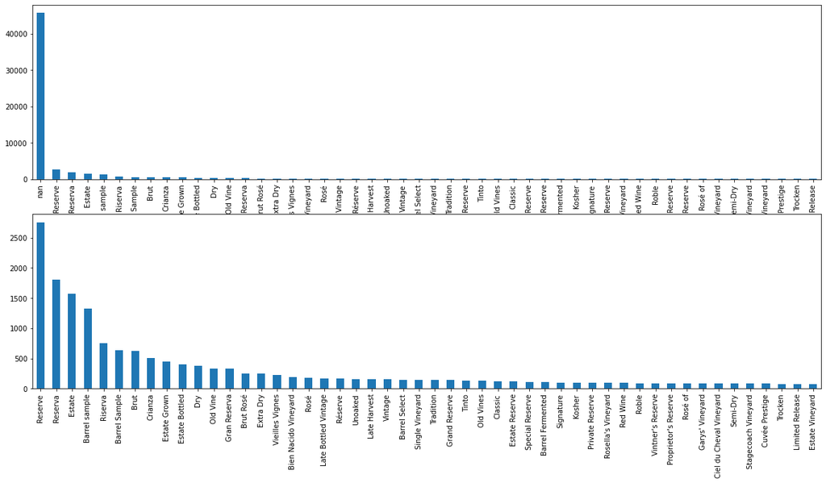

```python
attri = "designation"
matplotlib.pyplot.subplot(2,1,1)
data_15k[attri].value_counts(dropna = False)[:50].plot(kind='bar',figsize=(20,10))
matplotlib.pyplot.subplot(2,1,2)
d[attri].value_counts(dropna = False)[:50].plot(kind='bar',figsize=(20,10))
```

### 3.2.2 处理price属性缺失

可能原因是该种葡萄酒的价格无法获取,用最高频率值来填补缺失值

```python
attri = "price"
mode = data_15k[attri].mode()
f = data_15k[attri].fillna(int(mode))
print(f)
```

```
0         235.0
1         110.0
2          90.0
3          65.0
4          66.0
          ...
150925     20.0
150926     27.0
150927     20.0
150928     52.0
150929     15.0
Name: price, Length: 150930, dtype: float64
```

可视化对比

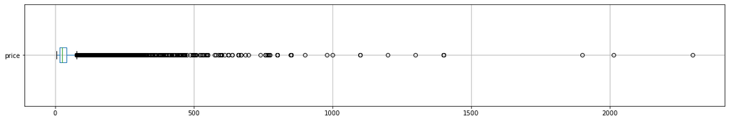

```python
data_15k.boxplot([attri],vert=False,figsize=(20,3))
```

[output not shown]

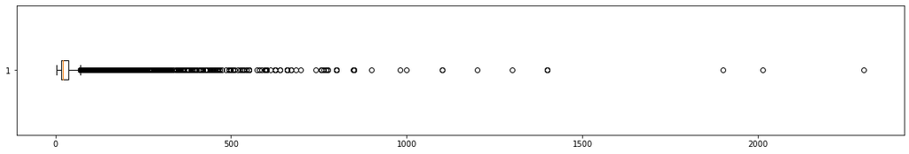

```python
matplotlib.pyplot.figure(figsize=(20,3))
matplotlib.pyplot.boxplot(f,vert=False)
```

### 3.2.3 处理region_1属性缺失

```python
attri = "region_1"
mode = data_15k[attri].mode()
f = data_15k[attri].fillna(str(mode))
print(f)
```

```
0               Napa Valley
1                      Toro
2            Knights Valley
3         Willamette Valley
4                    Bandol
                ...
150925    Fiano di Avellino
150926            Champagne
150927    Fiano di Avellino
150928            Champagne
150929           Alto Adige
Name: region_1, Length: 150930, dtype: object
```

可视化对比，直方图只显示前50项

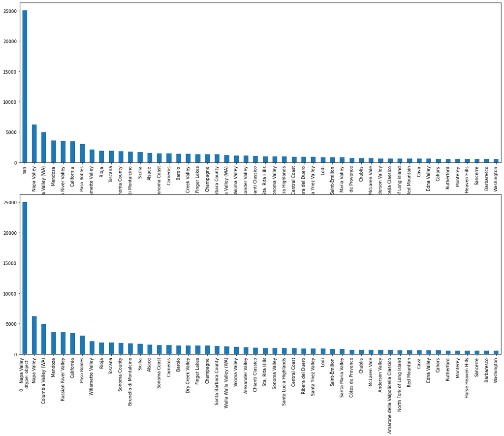

```python
attri = "region_1"
matplotlib.pyplot.subplot(2,1,1)
data_15k[attri].value_counts(dropna = False)[:50].plot(kind='bar',figsize=(20,15))
matplotlib.pyplot.subplot(2,1,2)
f.value_counts(dropna = False)[:50].plot(kind='bar',figsize=(20,15))
```

### 3.2.4 处理region_2属性缺失

可能原因是部分数据不存在region_2的属性

这里，将缺失部分剔除

```python
attri = "region_2"
new_region_2 = data_15k.dropna(subset=[attri])
print(new_region_2[attri].value_counts(dropna = False))
new_region_2
```

```
Central Coast              13057
Sonoma                     11258
Columbia Valley             9157
Napa                        8801
California Other            3516
Willamette Valley           3181
Mendocino/Lake Counties     2389
Sierra Foothills            1660
Napa-Sonoma                 1645
Finger Lakes                1510
Central Valley              1115
Long Island                  771
Southern Oregon              662
Oregon Other                 661
North Coast                  632
Washington Other             593
South Coast                  198
New York Other               147
Name: region_2, dtype: int64
```

|  | Unnamed: 0 | country | description | designation | points | price | province | region_1 | region_2 | variety | winery |
| --- | --- | --- | --- | --- | --- | --- | --- | --- | --- | --- | --- |
| 0 | 0 | US | This tremendous 100% varietal wine hails from ... | Martha's Vineyard | 96 | 235.0 | California | Napa Valley | Napa | Cabernet Sauvignon | Heitz |
| 2 | 2 | US | Mac Watson honors the memory of a wine once ma... | Special Selected Late Harvest | 96 | 90.0 | California | Knights Valley | Sonoma | Sauvignon Blanc | Macauley |
| 3 | 3 | US | This spent 20 months in 30% new French oak, an... | Reserve | 96 | 65.0 | Oregon | Willamette Valley | Willamette Valley | Pinot Noir | Ponzi |
| 8 | 8 | US | This re-named vineyard was formerly bottled as... | Silice | 95 | 65.0 | Oregon | Chehalem Mountains | Willamette Valley | Pinot Noir | Bergström |
| 9 | 9 | US | The producer sources from two blocks of the vi... | Gap's Crown Vineyard | 95 | 60.0 | California | Sonoma Coast | Sonoma | Pinot Noir | Blue Farm |
| ... | ... | ... | ... | ... | ... | ... | ... | ... | ... | ... | ... |
| 150892 | 150892 | US | A light, earthy wine, with violet, berry and t... | Coastal | 82 | 10.0 | California | California | California Other | Merlot | Callaway |
| 150896 | 150896 | US | Some raspberry fruit in the aroma, but things ... | NaN | 82 | 10.0 | California | California | California Other | Pinot Noir | Camelot |
| 150914 | 150914 | US | Old-gold in color, and thick and syrupy. The a... | Late Harvest Cluster Select | 94 | 25.0 | California | Anderson Valley | Mendocino/Lake Counties | White Riesling | Navarro |
| 150915 | 150915 | US | Decades ago, Beringer’s then-winemaker Myron N... | Nightingale | 93 | 30.0 | California | North Coast | North Coast | White Blend | Beringer |
| 150916 | 150916 | US | An impressive wine that presents a full bouque... | J. Schram | 93 | 65.0 | California | Napa Valley | Napa | Champagne Blend | Schramsberg |

60953 rows × 11 columns

可视化对比

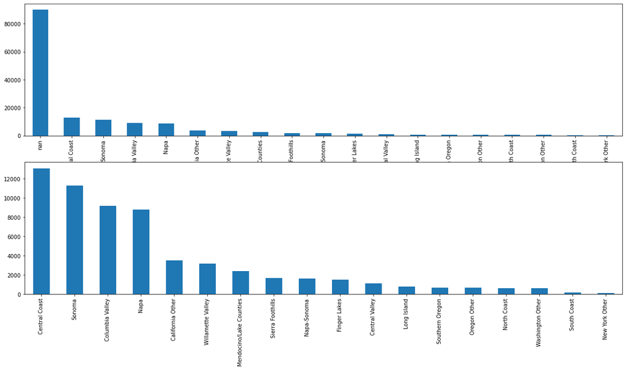

```python
attri = "region_2"
matplotlib.pyplot.subplot(2,1,1)
data_15k[attri].value_counts(dropna = False).plot(kind='bar',figsize=(20,10))
matplotlib.pyplot.subplot(2,1,2)
new_region_2[attri].value_counts(dropna = False).plot(kind='bar',figsize=(20,10))
```